# Reproducible Research: Peer Assessment 1

Steve Sapol

## Part 1: Loading and preprocessing the data

1. Load the required packages:

```r
library(ggplot2)
library(readr)
library(plyr)
```

2. Read in the data set:

```r
activity <- read_csv("~/activity.csv")
```

## Part 2: What is the mean total number of steps taken per day?

1. Create a histogram of the total number of steps per day:

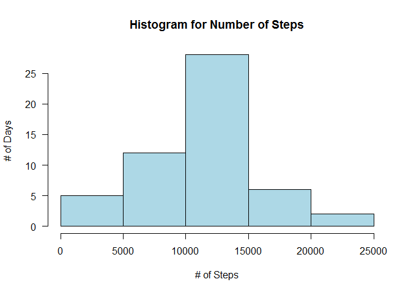

```r
#Aggregate by day
bydate <- aggregate(activity["steps"], by=activity["date"], sum)

#Plot the histogram
hist(bydate$steps,
     main="Histogram for Number of Steps",
     xlab="# of Steps",
     ylab="# of Days",
     col="light blue",
     las=1,
     breaks=5)
```

2. Calculate and report the mean total number of steps taken per day:

```r
#Calculate Mean (Removed NA Values)
mean(bydate$steps, na.rm = TRUE)
```

```
## [1] 10766.19
```

3. Calculate and report the median number of steps taken per day:

```r
#Calculate Mean (Removed NA Values)
median(bydate$steps, na.rm = TRUE)
```

```
## [1] 10765
```

## Part 3: What is the average daily activity pattern?

1. Create a time series plot of the 5-minute interval and the average number of steps taken, averaged across all days.

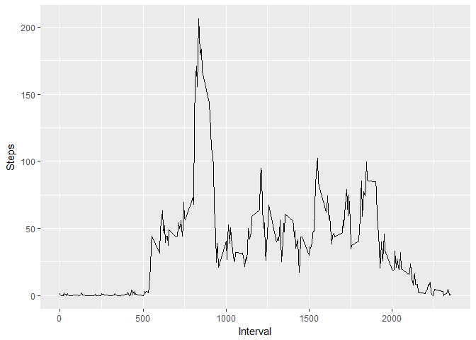

```r
#Interval Aggregate
byinterval <- aggregate(activity["steps"], by=activity["interval"], mean, na.rm = TRUE)

#Plot Time Series
ggplot(byinterval, aes(interval, steps)) + geom_line() +
  xlab("Interval") + ylab("Steps")
```

2. Identify the 5-minute interval that contains the maximum number of steps.

```r
#Determine interval with max steps
maxsteps <- byinterval[which.max(byinterval$steps),]

#The max number of steps is at
maxsteps$interval
```

```
## [1] 835
```

## Part 4: Imputing Missing Values

1. Calculate the total number of missing values in the data set.

```r
#Total NAs
sum(is.na(activity$steps))
```

```
## [1] 2304
```

2. Devise a strategy for filling in all of the missing values and create a new dataset.

```r
#Create new actitity table replacing NA with average by interval
activitynew <- activity

activitynew$steps <- with(activitynew, ave(steps, interval,
                          FUN = function(x) replace(x, is.na(x), mean(x, na.rm = TRUE))))
```

3. Make a histogram of the total number of steps take each day.

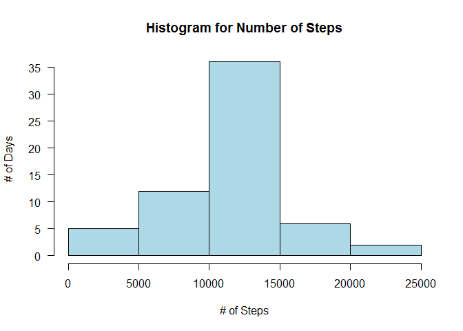

```r
#aggregate new by day
bydatenew <- aggregate(activitynew["steps"], by=activitynew["date"], sum)

#Histogram of number of steps by day
hist(bydatenew$steps,
     main="Histogram for Number of Steps",
     xlab="# of Steps",
     ylab="# of Days",
     col="light blue",
     las=1,
     breaks=5)
```

4. Calculate and report the mean total number of steps taken per day:

```r
#Calculate Mean
mean(bydatenew$steps)
```

```
## [1] 10766.19
```

5. Calculate and report the median number of steps taken per day:

```r
#Calculate Mean
median(bydatenew$steps)
```

```
## [1] 10766.19
```

## Part 5: Are there differences in activity patterns between weekdays and weekends.

1. Create a new factor, “Weekday” and “Weekend”

```r
activity$day <- weekdays(activity$date)
activity$weekend <- revalue(activity$day,
                            c("Monday" = "Weekday",
                              "Tuesday" = "Weekday",
                              "Wednesday" = "Weekday",
                              "Thursday" = "Weekday",
                              "Friday" = "Weekday",
                              "Saturday" = "Weekend",
                              "Sunday" = "Weekend"))

#Aggregate by day and By weekend
bydayinterval <- aggregate(steps ~ weekend+interval, data = activity, mean, na.rm = TRUE)
```

2. Make a panel plot comparing the two.

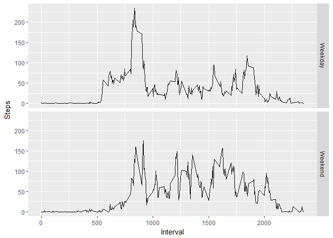

```r
#Panel Plot - Weekend
p <- ggplot(bydayinterval, aes(interval, steps)) + geom_line() +
  xlab("Interval") + ylab("Steps")

p + facet_grid(weekend~.)
```